# Joint inference of misaligned irregular time series with application to Greenland ice core data

T. K. Doan, J. Haslett, and A. C. Parnell

10 Februar 2017

Abstract. Ice cores provide insight into the past climate over many millennia. Due to ice compaction, the raw data for any single core are irregular in time. Multiple cores have different irregularities; and when considered together, they are misaligned in time. After processing, such data are made available to researchers as regular time series: a data product. Typically, these cores are independently processed. This paper considers a fast Bayesian method for the joint processing of multiple irregular series. This is shown to be more efficient than the independent alternative. Furthermore, our explicit framework permits a reliable modelling of the impact of the multiple sources of uncertainty. The methodology is illustrated with the analysis of a pair of ice cores. Our data products, in the form of posterior marginals or joint distributions on an arbitrary temporal grid, are finite Gaussian mixtures. We can also produce process histories to study non-linear functionals of interest. More generally, the concept of joint analysis via hierarchical Gaussian process models can be widely extended, as the models used can be viewed within the larger context of continuous spaceâ“time processes.

[output not shown]

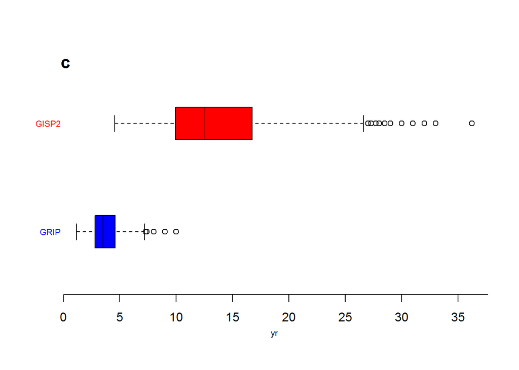

```
## 25% 50% 75%
## 2.8 3.5 4.6
```

```
##   25%   50%   75%
##  9.94 12.52 16.78
```

```
## 25% 50% 75%
## 2.8 3.5 4.6
```

```
##   25%   50%   75%
##  9.94 12.52 16.78
```

```r
###################
### Variograms calculations
var.gisp <- as.geodata(data.frame(coords = t(rbind(age.gisp, rep(1, n.gisp))), data=d18O.gisp))
var.grip <- as.geodata(data.frame(coords = t(rbind(age.grip, rep(1, n.grip))), data=d18O.grip))
gisp.vario.b <- variog(var.gisp, uvec=seq(0, 3.5, 0.1))  # binned variogram of the Holocene
```

```
## variog: computing omnidirectional variogram
```

```r
grip.vario.b <- variog(var.grip, uvec=seq(0, 3.5, 0.1))
```

```
## variog: computing omnidirectional variogram
```

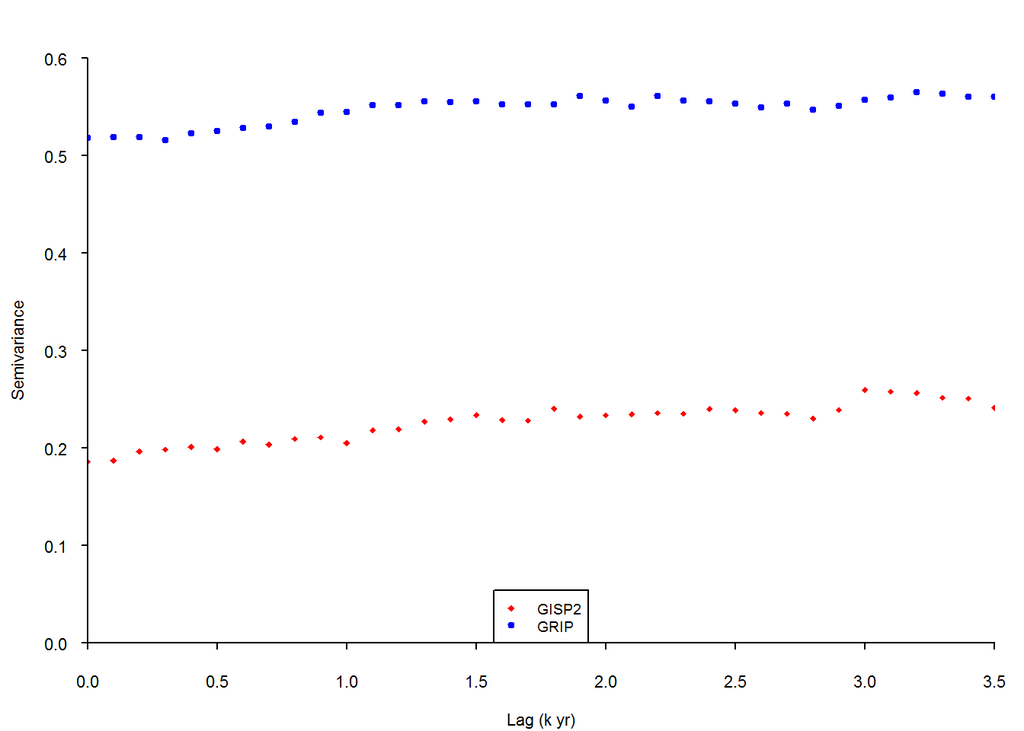

```r
# Plots of the empirical semivariograms
par(mar=c(3,3,2,1), mgp=c(2,.7,0), tck=-.01)
plot(gisp.vario.b$u, gisp.vario.b$v, xlab='', ylab='',col=2,pch=18, bty='n', cex=0.6,
     ylim=c(0,0.6), lwd=2, cex.lab=0.7, cex.axis=0.7, xaxs="i",yaxs="i", las=1)
points(grip.vario.b$u, grip.vario.b$v, pch=20, col=4, lwd=2, cex=0.6)
mtext('Lag (k yr)', side=1, line=2, cex=0.7)
mtext('Semivariance', side=2, line=2, cex=0.7)
legend('bottom', c('GISP2','GRIP'), pch=c(18,20), lty=-1, col=c(2,4), cex=0.6, bty='y', lwd=2)
```

```r
# Weighted least squared method to estimate parameters, assuming the linear variogram model is a correct
# data generation mechanism
init.gisp <- variofit(gisp.vario.b, cov.model='linear', weights='cressie')
```

```
## variofit: covariance model used is linear
## variofit: weights used: cressie
## variofit: minimisation function used: optim
```

```
## variofit: searching for best initial value ... selected values:
##               sigmasq phi   tausq  kappa
## initial.value "0.26"  "0"   "0.13" "0.5"
## status        "est"   "est" "est"  "fix"
## loss value: 7680.06930431104
```

```r
init.grip <- variofit(grip.vario.b, cov.model='linear', weights='cressie')
```

```
## variofit: covariance model used is linear
## variofit: weights used: cressie
## variofit: minimisation function used: optim
```

```
## variofit: searching for best initial value ... selected values:
##               sigmasq phi   tausq  kappa
## initial.value "0.57"  "0"   "0.28" "0.5"
## status        "est"   "est" "est"  "fix"
## loss value: 330588.190603372
```

```r
sigmasq.gisp.est <- max(init.gisp$nugget, 1E-6)  # tau.gisp <- 1/(0.14^2)
sigmasq.grip.est <- max(init.grip$nugget, 1E-6)  # tau.grip <- 1/(0.05^2)
v.gisp.est <- max(1E-6, init.gisp$cov.pars[1])*2
v.grip.est <- max(1E-6, init.grip$cov.pars[1])*2

#scaled distribution of first differences
gisp.qq <- diff(d18O.gisp)/sqrt(v.gisp.est*diff(age.gisp)+ 2*sigmasq.gisp.est)
grip.qq <- diff(d18O.grip)/sqrt(v.grip.est*diff(age.grip)+ 2*sigmasq.grip.est)

gisp.probs = (1:(n.gisp-1))/(n.gisp)
n.quant1 = qnorm(gisp.probs, mean(gisp.qq, na.rm = T), sd(gisp.qq, na.rm = T))
grip.probs = (1:(n.grip-1))/(n.grip)
n.quant2 = qnorm(grip.probs, mean(grip.qq, na.rm = T), sd(grip.qq, na.rm = T))
```

```r
# QQ plots
par(mar=c(3,3,2,1), mgp=c(2,.7,0), tck=-.01)
par(mfrow=c(1,2))
plot(sort(gisp.qq) , sort(n.quant1), ylab = '', xlab = '',
     cex.lab=0.7, cex.axis=0.7, las=1, bty='n', col=2, pch=21, axes=F, xlim=c(-5.4,4), cex=.6)
abline(0,1, lwd=2, col=3)
title(outer=F, adj=.1, main="a", cex.main=0.9, col="black", font=2, line=0)
mtext("Theoretical quantiles", side=2, line=2, at=0, font=1, cex=0.7)
mtext("Empirical quantiles", side=1, line=2, at=0, las=1, font=1, cex=0.7)
axis(side=1, at = seq(-4, 4, by=2), labels=T, cex.axis=0.7, las=1)
axis(side=2, at = seq(-4, 4, by=2), labels=T, cex.axis=0.7, las=1)

plot(sort(grip.qq) , sort(n.quant2), ylab = '', xlab = '', cex=.6,
     cex.lab=0.7, cex.axis=0.7, las=1, bty='n', col=4, pch=21, axes=F, xlim=c(-5.4,4))
abline(0,1, lwd=2, col=3)
mtext("Theoretical quantiles", side=2, line=2, at=0, font=1, cex=0.7)
mtext("Empirical quantiles", side=1, line=2, at=0, las=1, font=1, cex=0.7)
title(outer=F, adj=.1, main="b", cex.main=0.9, col="black", font=2, line=0)
axis(side=1, at = seq(-4, 4, by=2), labels=T, cex.axis=0.7, las=1)
axis(side=2, at = seq(-4, 4, by=2), labels=T, cex.axis=0.7, las=1)
```

[output not shown]